# HDIsummary

# Introduction

This vignette explains how to use the `HDIsummary` library to read in, summarise, print, and plot HDI data for different countries. This allows users to easily compare HDI data across countries.

We will compare two difference countries: Nigeria and Singapore.

We begin by reading in our data below.

```r
library(HDIsummary)

nga_link = "https://data.humdata.org/dataset/85a5d168-88c9-43fe-b535-f4215d9177f3/resource/b1dceca0-1dbc-4bc5-aca6-9c8c59b4e505/download/hdro_indicators_nga.csv"

sgp_link = "https://data.humdata.org/dataset/0f45cb7e-e702-462e-94ba-c746f79cefc5/resource/95ec52d0-5bba-417a-b406-a09e58506ea3/download/hdro_indicators_sgp.csv"

HDIdata_sgp = read_HDI(sgp_link)
HDIdata_nga = read_HDI(nga_link)
```

## Print Function

The print function returns the number of observations, the column names, the country name, the individual indicators and the indices which they belong to.

### Singapore

```r
print(HDIdata_sgp)
```

```
#> HDIdata object with 894 observations
#> Column names:
#>  country_code
#> country_name
#> indicator_id
#> indicator_name
#> index_id
#> index_name
#> value
#> year
#>
#> Country:
#>  Singapore
#>
#> Indicators:
#>  Adolescent Birth Rate (births per 1,000 women ages 15-19)
#> Carbon dioxide emissions per capita (production) (tonnes)
#> Coefficient of human inequality
#> Difference from HDI value (%)
#> Expected Years of Schooling (years)
#> Expected Years of Schooling, female (years)
#> Expected Years of Schooling, male (years)
#> GDI Group
#> GII Rank
#> Gross National Income Per Capita, female (2017 PPP$)
#> Gross National Income Per Capita, male (2017 PPP$)
#> Gross National Income Per Capita (2017 PPP$)
#> HDI female
#> HDI male
#> HDI Rank
#> Inequality in eduation
#> Inequality in income
#> Inequality in life expectancy
#> Life Expectancy at Birth (years)
#> Life Expectancy at Birth, female (years)
#> Life Expectancy at Birth, male (years)
#> Labour force participation rate, female (% ages 15 and older)
#> Labour force participation rate, male (% ages 15 and older)
#> Overall loss (%)
#> Material footprint per capita (tonnes)
#> Maternal Mortality Ratio (deaths per 100,000 live births)
#> Mean Years of Schooling (years)
#> Mean Years of Schooling, female (years)
#> Mean Years of Schooling, male (years)
#> Share of seats in parliament, female (% held by women)
#> Share of seats in parliament, male (% held by men)
#> Difference from HDI rank
#> Population with at least some secondary education, female (% ages 25 and older)
#> Population with at least some secondary education, male (% ages 25 and older)
#>
#> Indices which indicators belong to:
#>  Gender Inequality Index
#> Planetary pressuresâ€“adjusted Human Development Index
#> Inequality-adjusted Human Development Index
#> Human Development Index
#> Gender Development Index
```

### Nigeria

```r
print(HDIdata_nga)
```

```
#> HDIdata object with 777 observations
#> Column names:
#>  country_code
#> country_name
#> indicator_id
#> indicator_name
#> index_id
#> index_name
#> value
#> year
#>
#> Country:
#>  Nigeria
#>
#> Indicators:
#>  Adolescent Birth Rate (births per 1,000 women ages 15-19)
#> Assets (%)
#> Child mortality (%)
#> Carbon dioxide emissions per capita (production) (tonnes)
#> Coefficient of human inequality
#> Cooking fuel (%)
#> Difference from HDI value (%)
#> Drinking water (%)
#> Electricity (%)
#> Expected Years of Schooling (years)
#> Expected Years of Schooling, female (years)
#> Expected Years of Schooling, male (years)
#> GDI Group
#> GII Rank
#> Gross National Income Per Capita, female (2017 PPP$)
#> Gross National Income Per Capita, male (2017 PPP$)
#> Gross National Income Per Capita (2017 PPP$)
#> HDI female
#> HDI male
#> HDI Rank
#> Housing (%)
#> Inequality in eduation
#> Inequality in income
#> Inequality in life expectancy
#> Life Expectancy at Birth (years)
```

[output cut: 12 more lines]

```
#> Share of seats in parliament, male (% held by men)
#> Difference from HDI rank
#> Sanitation (%)
#> School attendance (%)
#> Population with at least some secondary education, female (% ages 25 and older)
#> Population with at least some secondary education, male (% ages 25 and older)
#> Years of schooling (%)
#>
#> Indices which indicators belong to:
#>  Gender Inequality Index
#> Multidimensional Poverty Index
#> Planetary pressuresâ€“adjusted Human Development Index
#> Inequality-adjusted Human Development Index
#> Human Development Index
#> Gender Development Index
```

### Singapore and Nigeria Comparison

We can see that the indicators between the two datasets are not the same and this seems to be due to the `Multidimensional Poverty Index` not being featured in the Singapore dataset. A researcher may want to focus on the common indicators for analysis or investigate this further.

## Sumary Function

The summary function first returns the number of observations, the number of indicators, the the range of years.

It then returns the mean, median, min, max, years of data, and missing values for each indicator.

The final output is a summary of the data completeness for each indicator.

### Singapore

The detailed output is provided below and a researcher can pick and choose which to focus on.

```r
summary(HDIdata_sgp)
```

```
#> HDIdata Summary
#> Observations: 894
#> Indicators: 34
#> Years: 1990 2022
#>
#> Summary for Adolescent Birth Rate (births per 1,000 women ages 15-19) :
#> Mean: 5.636636
#> Median: 6.421
#> Min: 2.275
#> Max: 8.918
#> Years of data: 33
#> Missing Values: 0
#>
#> Summary for Carbon dioxide emissions per capita (production) (tonnes) :
#> Mean: 10.69888
#> Median: 10.023
#> Min: 5.758
#> Max: 17.474
#> Years of data: 33
#> Missing Values: 0
#>
#> Summary for Coefficient of human inequality :
#> Mean: 13.03192
#> Median: 13.096
#> Min: 12.534
#> Max: 13.51
#> Years of data: 13
#> Missing Values: 0
#>
#> Summary for Difference from HDI value (%) :
#> Mean: 21.34021
#> Median: 20.128
#> Min: 15.784
#> Max: 35.816
#> Years of data: 33
#> Missing Values: 0
#>
#> Summary for Expected Years of Schooling (years) :
#> Mean: 15.93297
#> Median: 15.938
```

[output cut: 227 more lines]

```
#> Missing Values: 0
#>
#> Summary for Population with at least some secondary education, male (% ages 25 and older) :
#> Mean: 72.64788
#> Median: 76.003
#> Min: 37.976
#> Max: 85.932
#> Years of data: 33
#> Missing Values: 0
#>
#> Data Completeness (percentage of non-NA values):
#>   country_code   country_name   indicator_id indicator_name       index_id
#>            100            100            100            100            100
#>     index_name          value           year
#>            100            100            100
```

### Nigeria

Again, the detailed output is provided below and a researcher can pick and choose which to focus on.

```r
summary(HDIdata_nga)
```

```
#> HDIdata Summary
#> Observations: 777
#> Indicators: 44
#> Years: 1990 2022
#>
#> Summary for Adolescent Birth Rate (births per 1,000 women ages 15-19) :
#> Mean: 124.6288
#> Median: 128.112
#> Min: 99.56
#> Max: 140.866
#> Years of data: 33
#> Missing Values: 0
#>
#> Summary for Assets (%) :
#> Mean: 4.945
#> Median: 4.945
#> Min: 4.945
#> Max: 4.945
#> Years of data: 1
#> Missing Values: 0
#>
#> Summary for Child mortality (%) :
#> Mean: 19.473
#> Median: 19.473
#> Min: 19.473
#> Max: 19.473
#> Years of data: 1
#> Missing Values: 0
#>
#> Summary for Carbon dioxide emissions per capita (production) (tonnes) :
#> Mean: 0.6472121
#> Median: 0.641
#> Min: 0.408
#> Max: 0.882
#> Years of data: 33
#> Missing Values: 0
#>
#> Summary for Coefficient of human inequality :
#> Mean: 33.94983
#> Median: 33.4935
```

[output cut: 307 more lines]

```
#> Missing Values: 0
#>
#> Summary for Years of schooling (%) :
#> Mean: 15.876
#> Median: 15.876
#> Min: 15.876
#> Max: 15.876
#> Years of data: 1
#> Missing Values: 0
#>
#> Data Completeness (percentage of non-NA values):
#>   country_code   country_name   indicator_id indicator_name       index_id
#>            100            100            100            100            100
#>     index_name          value           year
#>            100            100            100
```

### Singapore and Nigeria Comparison

We note that Singapore scores higher on most metrics as a result of its higher levels of development compared to Nigeria. However, the detailed output is unwieldy. The plot function provides a better way to easily compare countries based on key indicators.

## Plot Function

The plot function returns a `ggplot2` object which provides a visual representation of the HDI data for the country by focusing on the trend of four central indicators over time: Adolescent Birth Rate, Life Expectancy at Birth, Mean Years of Schooling, and Gross National Income Per Capita.

This is particularly useful for comparing the HDI data of different countries at a glance while the summary function provides a more detailed overview of the data for researchers who wish to investigate further.

### Singapore

We see positive developments in all indicators.

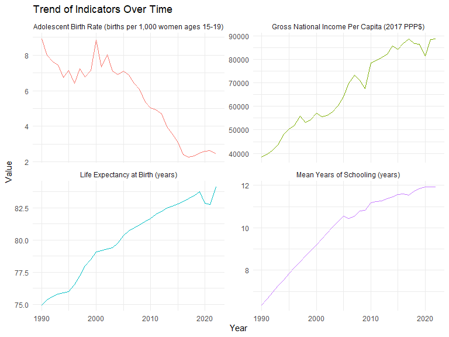

```r
p1 = plot(HDIdata_sgp)
p1
```

### Nigeria

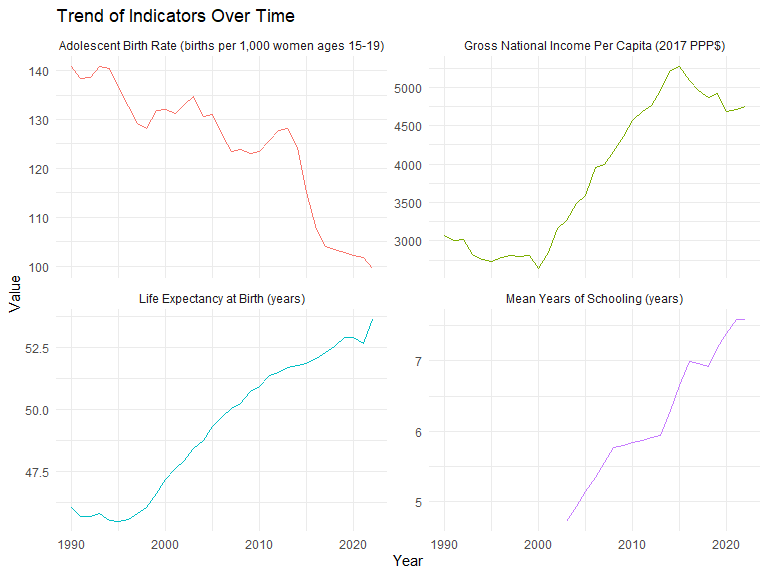

```r
p2 = plot(HDIdata_nga)
p2
```

### Singapore and Nigeria Comparison

Both countries are on positive trajectories despite the different values on their axes which reflect differing levels of development.

# Conclusion

The `HDIsummary` package provides a simple way to read in, summarise, print, and plot HDI data for different countries.

By easily comparing HDI data across countries, researchers can quickly identify trends and patterns in the data which can be used to inform further analysis and research.

In this case, we highlighted two countries with differing levels of development but which are both on positive trajectories. But the package can be used to compare any two countries of interest, and a particularly interesting area of research would be to compare countries which are not necessarily on positive trajectories - a country such as Afghanistan, for example, which has been in conflict for many years.